# Introduction to BigQuery: Course Completion and Learning Notes

Author

Yushan Huang

Published

October 4, 2026

# 1 Course-Completion Evidence

I completed all four chapters of the DataCamp **Introduction to BigQuery** course in October 2026. The course covered BigQuery architecture and data organization, writing queries and working with data types, analytical querying with CTEs and window functions, and data management and query optimization.

The screenshots below show my completed course chapters.

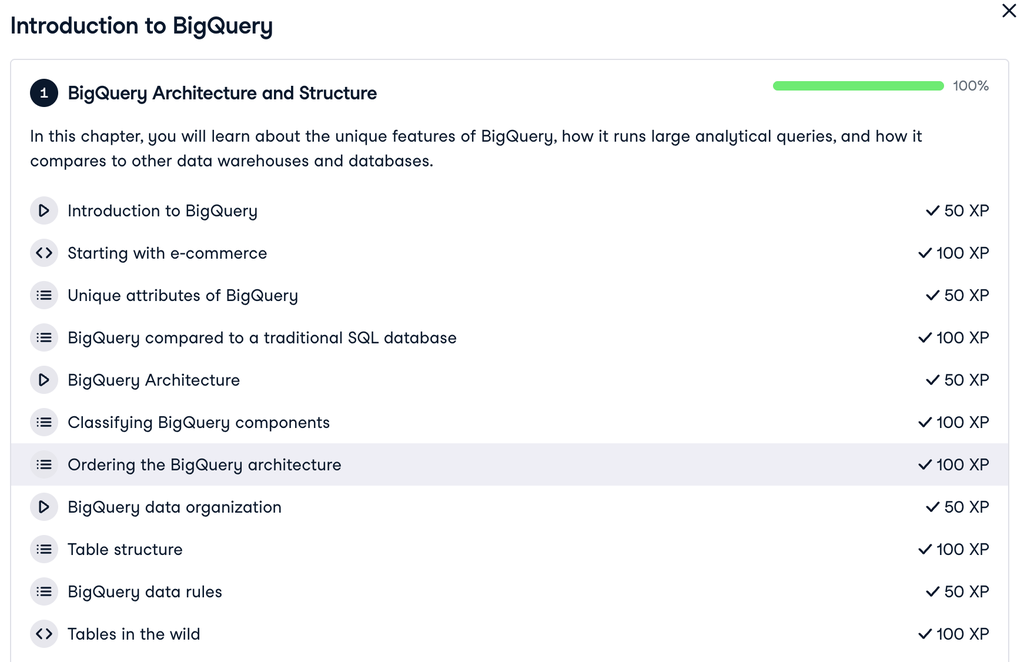

Chapter 1: BigQuery Architecture and Structure completed

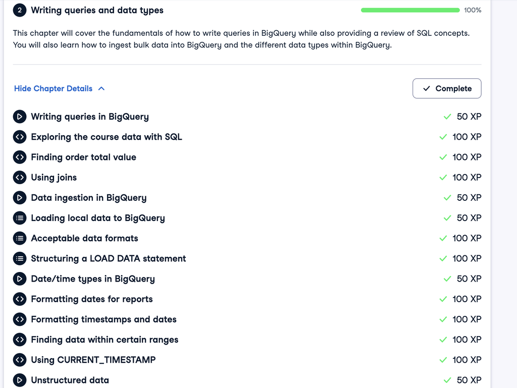

Chapter 2: Writing queries and data types completed

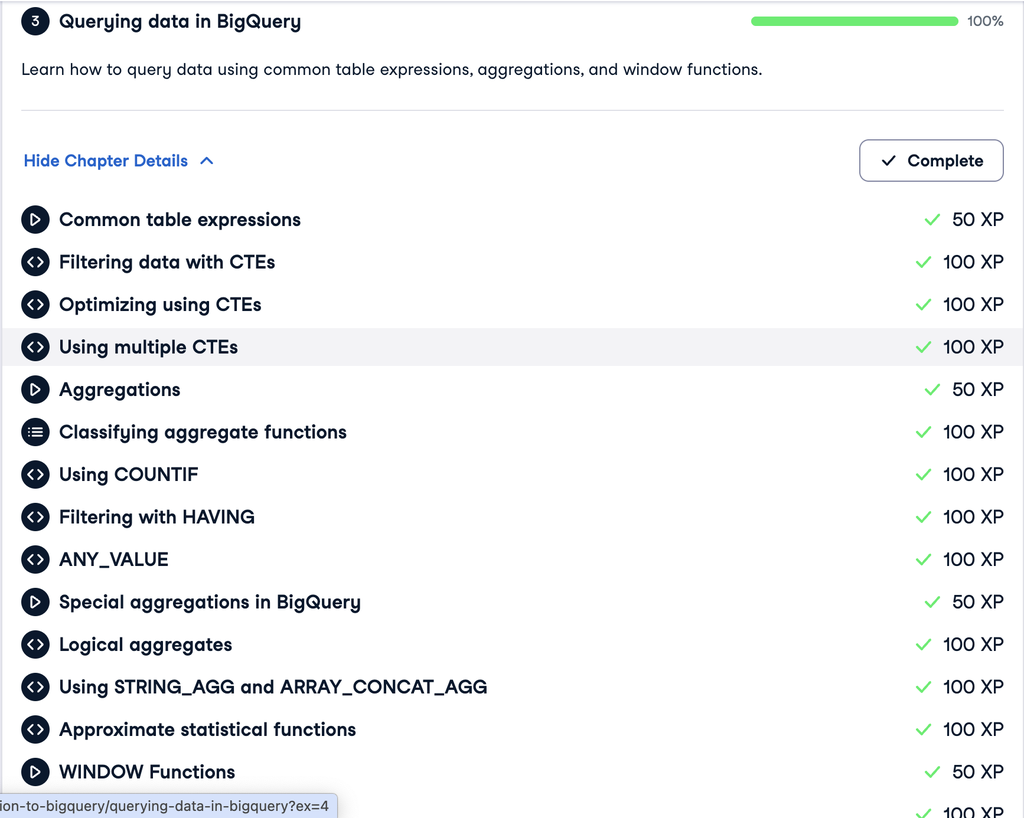

Chapter 3: Querying data in BigQuery completed

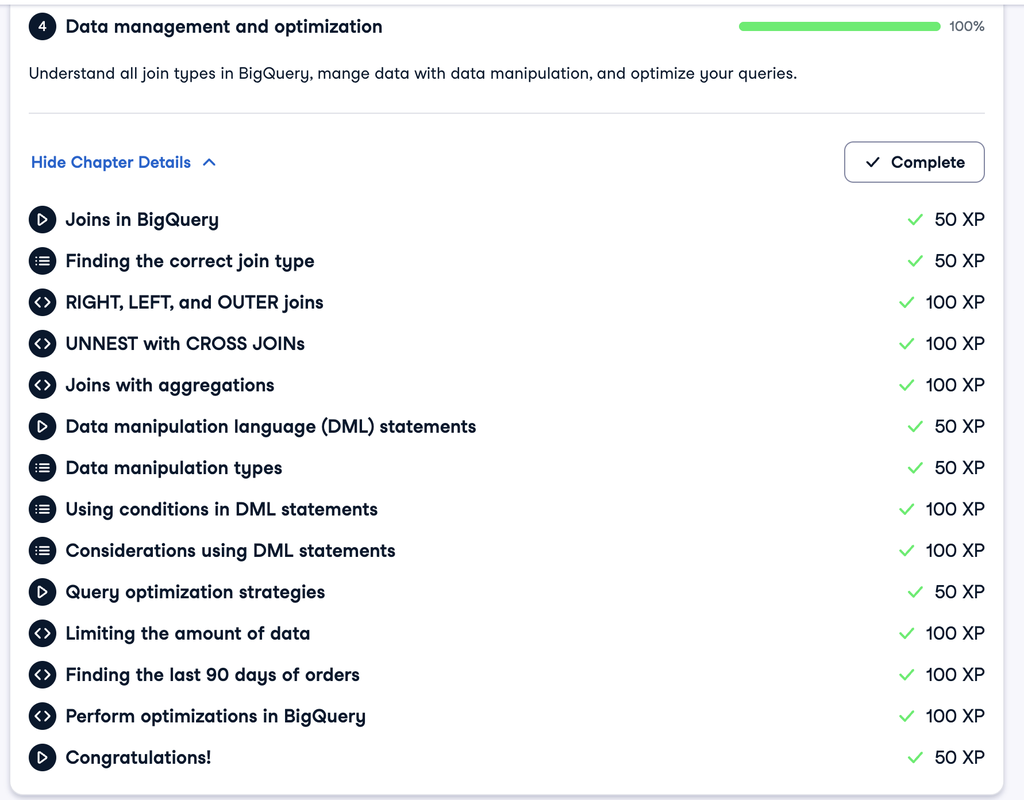

Chapter 4: Data management and optimization completed

# 2 Learning Notes and Key Takeaways

## 2.1 Chapter 1: BigQuery Architecture and Structure

### 2.1.1 Main ideas

BigQuery is a cloud-based analytical data warehouse designed for large datasets and analytical workloads. A major feature is the separation of **storage** and **compute**. This architecture allows BigQuery to store large amounts of data while using separate computing resources to execute queries. BigQuery is especially appropriate for large analytical and distributed query workloads rather than highly transactional database workloads.

### 2.1.2 Architecture and terminology

The course introduced several components that work together in BigQuery:

- **Colossus** and **Capacitor** are associated with storage.
- **Dremel** is the distributed query execution engine.
- Dremel uses **execution trees, leaf nodes, mixers, and slots** to distribute query processing.
- **Borg** and **Jupiter** are part of the computing infrastructure.

A simple way I remember the architecture is:

```
Storage                  Query execution                 Computing
Colossus                 Dremel                          Borg
Capacitor                execution trees                Jupiter
                         leaf nodes
                         mixers and slots
```

### 2.1.3 BigQuery data organization

BigQuery organizes data hierarchically:

```
Project
  └── Dataset
        └── Table
```

For example, `ecommerce.ecomm_order_details` refers to the `ecomm_order_details` table inside the `ecommerce` dataset. Data location also matters. The course emphasized planning the region where data is stored because queries across datasets depend on compatible locations and appropriate access.

### 2.1.4 Basic SQL examples

A quick way to preview a table is:

```sql
SELECT *
FROM ecommerce.ecomm_order_details
LIMIT 3;
```

`SELECT *` returns all columns, while `LIMIT 3` restricts the output to three rows.

To return unique seller cities:

```sql
SELECT DISTINCT seller_city
FROM ecommerce.ecomm_sellers;
```

`DISTINCT` removes duplicate values and returns each seller city once.

### 2.1.5 CEP application

The project-dataset-table structure could help me organize CEP data into logical groups such as customers, transactions, campaigns, survey responses, or website behavior. BigQuery’s distributed architecture would be useful if a marketing project contained datasets too large to analyze efficiently on a local computer.

## 2.2 Chapter 2: Writing Queries and Data Types

### 2.2.1 Main ideas

This chapter reviewed SQL fundamentals in BigQuery and introduced data ingestion, date/time functions, and nested or unstructured data. The main lesson for me was that BigQuery is not only about SQL syntax; it also requires understanding how data is loaded, structured, and stored.

### 2.2.2 Selecting only necessary columns

Instead of always using `SELECT *`, I can request only the columns needed:

```sql
SELECT
    order_id,
    customer_id,
    order_status,
    order_purchase_timestamp
FROM ecommerce.ecomm_order_details
LIMIT 10;
```

This makes the result easier to read and avoids querying unnecessary columns.

### 2.2.3 Aggregating and ordering results

To find the ten smallest orders by total payment value:

```sql
SELECT
    order_id,
    SUM(payment_value) AS total_payment
FROM ecommerce.ecomm_payments
GROUP BY order_id
ORDER BY SUM(payment_value) ASC
LIMIT 10;
```

`SUM()` calculates the total payment value for each order. `GROUP BY` produces one result per order, and `ASC` places the smallest totals first.

### 2.2.4 Joining tables

Information can be stored across different tables. The following query joins two tables through their common `order_id` column:

```sql
SELECT
    ecomm_orders.order_id,
    ecomm_orders.order_items,
    ecomm_order_details.order_status,
    ecomm_order_details.order_purchase_timestamp
FROM ecommerce.ecomm_orders
JOIN ecommerce.ecomm_order_details USING (order_id)
ORDER BY order_purchase_timestamp DESC
LIMIT 10;
```

`USING (order_id)` is convenient when both tables use the same join-column name. `DESC` places the most recent orders first.

### 2.2.5 Loading data into BigQuery

The course introduced several common data formats that BigQuery can ingest, including **CSV, JSON, Avro, Parquet, and ORC**. The local-data exercise emphasized that local uploads have a relatively small file-size limit and that `LOAD DATA` is not used to load a file directly from a local computer.

For data stored in cloud storage, a `LOAD DATA` statement can follow this pattern:

```sql
LOAD DATA INTO mydataset.table
FROM FILES(
    uris = ['gs://bucket/path/file.csv'],
    format = 'CSV'
);
```

The URI identifies the cloud-storage file and `format` tells BigQuery how the source data is stored.

### 2.2.6 Dates and timestamps

To count orders in September:

```sql
SELECT
    COUNT(order_id)
FROM ecommerce.ecomm_order_details
WHERE EXTRACT(MONTH FROM order_purchase_timestamp) = 9;
```

To count orders in the fourth quarter of 2017:

```sql
SELECT
    COUNT(order_id)
FROM ecommerce.ecomm_order_details
WHERE EXTRACT(QUARTER FROM order_purchase_timestamp) = 4
  AND EXTRACT(YEAR FROM order_purchase_timestamp) = 2017;
```

A timestamp can be formatted for reporting:

```sql
SELECT
    FORMAT_TIMESTAMP("%D", order_purchase_timestamp) AS order_date,
    order_id
FROM ecommerce.ecomm_order_details
LIMIT 3;
```

`TIMESTAMP_ADD()` and `TIMESTAMP_SUB()` are useful for defining time windows. For example:

```sql
SELECT
    COUNT(order_id)
FROM ecommerce.ecomm_order_details
WHERE order_purchase_timestamp BETWEEN
    TIMESTAMP_SUB(TIMESTAMP('2017-11-24'), INTERVAL 3 DAY)
    AND TIMESTAMP_ADD(TIMESTAMP('2017-11-24'), INTERVAL 3 DAY);
```

This counts orders in the three days before and after Black Friday 2017.

### 2.2.7 Arrays, STRUCTs, SEARCH, and UNNEST

BigQuery can work with nested and repeated data. An array can be constructed with a subquery:

```sql
SELECT
    ARRAY(
        SELECT product_id
        FROM ecommerce.ecomm_products
        WHERE product_weight_g = 2220
    );
```

Nested `order_items` can be expanded with `UNNEST()`:

```sql
SELECT
    order_id,
    items.price
FROM ecommerce.ecomm_orders,
     UNNEST(order_items) AS items
WHERE order_id = 'a0e747c954a595b0e3458c87ab1a4958';
```

Dot notation such as `items.price` accesses a field inside the unnested structure. The course also introduced `SEARCH()` for finding values in suitable unstructured or semi-structured data.

### 2.2.8 CEP application

These techniques could support marketing analyses involving campaign dates, customer orders, transaction values, or nested event data. Date functions would help compare activity before and after a campaign, while `UNNEST()` could help analyze repeated products, events, or other nested records.

## 2.3 Chapter 3: Querying Data in BigQuery

### 2.3.1 Common table expressions (CTEs)

A Common Table Expression uses `WITH` to create a temporary named result. CTEs make complex queries easier to read and allow filtering or aggregation to happen before the final query.

For example, I can first keep orders containing an item priced above $150:

```sql
WITH orders AS (
    SELECT order_id
    FROM ecommerce.ecomm_orders,
         UNNEST(order_items) AS items
    WHERE items.price > 150
)

SELECT
    COUNT(order_id),
    order_status
FROM ecommerce.ecomm_order_details od
JOIN orders o USING (order_id)
GROUP BY order_status;
```

### 2.3.2 Optimizing with CTEs

A CTE can perform an aggregation before the main query:

```sql
WITH payments AS (
    SELECT
        MAX(payment_sequential) AS num_payments,
        order_id
    FROM ecommerce.ecomm_payments
    GROUP BY order_id
)

SELECT
    ARRAY_LENGTH(o.order_items) AS num_items,
    MAX(p.num_payments) AS max_payments
FROM ecommerce.ecomm_orders o
JOIN payments p USING (order_id)
GROUP BY ARRAY_LENGTH(o.order_items);
```

`ARRAY_LENGTH()` returns the number of elements in an array.

Multiple CTEs can separate stages of analysis:

```sql
WITH orders AS (
    SELECT
        order_id,
        items.product_id,
        items.price
    FROM ecommerce.ecomm_orders,
         UNNEST(order_items) AS items
    WHERE items.price > 100
),
products AS (
    SELECT
        product_id,
        AVG(product_weight_g) AS avg_weight
    FROM ecommerce.ecomm_products
    GROUP BY product_id
)

SELECT
    o.order_id,
    p.avg_weight
FROM orders o
JOIN products p
    ON p.product_id = o.product_id;
```

### 2.3.3 COUNTIF and HAVING

`COUNTIF()` performs a conditional count:

```sql
SELECT
    product_category_name_english,
    COUNTIF(product_weight_g > 5000) AS heavy_products
FROM ecommerce.ecomm_products
GROUP BY product_category_name_english;
```

`HAVING` filters aggregated results:

```sql
SELECT
    product_category_name_english,
    AVG(product_weight_g) AS avg_weight
FROM ecommerce.ecomm_products
GROUP BY product_category_name_english
HAVING AVG(product_weight_g) > 10000;
```

A useful distinction is that `WHERE` filters individual rows before aggregation, while `HAVING` filters groups after aggregation.

### 2.3.4 ANY_VALUE

GoogleSQL provides `ANY_VALUE()` for selecting a value from within an aggregated group. It can be combined with `HAVING MAX` or `HAVING MIN`:

```sql
SELECT
    product_weight_g,
    ANY_VALUE(
        product_category_name_english
        HAVING MAX product_photos_qty
    ) AS random_product
FROM ecommerce.ecomm_products
GROUP BY product_weight_g;
```

### 2.3.5 Logical aggregates

`LOGICAL_AND()` returns true only when every condition in the group is true:

```sql
SELECT
    customer_id,
    LOGICAL_AND(order_status = 'delivered') AS all_delivered
FROM ecommerce.ecomm_order_details
GROUP BY customer_id;
```

`LOGICAL_OR()` returns true when at least one condition is true:

```sql
SELECT
    customer_id,
    LOGICAL_OR(order_status = 'shipped') AS any_shipped
FROM ecommerce.ecomm_order_details
GROUP BY customer_id;
```

### 2.3.6 STRING_AGG and ARRAY_CONCAT_AGG

`STRING_AGG()` combines text values into one string:

```sql
SELECT
    o.order_id,
    STRING_AGG(
        DISTINCT product_category_name_english,
        ', '
    ) AS categories
FROM ecommerce.ecomm_orders o,
     UNNEST(order_items) AS items
JOIN ecommerce.ecomm_products p
    ON items.product_id = p.product_id
WHERE ARRAY_LENGTH(o.order_items) > 1
GROUP BY order_id;
```

`ARRAY_CONCAT_AGG()` aggregates arrays:

```sql
SELECT
    items.seller_id,
    ARRAY_CONCAT_AGG(order_items) AS seller_sales
FROM ecommerce.ecomm_orders,
     UNNEST(order_items) AS items
GROUP BY items.seller_id;
```

### 2.3.7 Approximate statistical functions

GoogleSQL provides approximate aggregate functions that can improve performance on large datasets when an exact result is not required. The course introduced:

- `APPROX_COUNT_DISTINCT`
- `APPROX_QUANTILES`
- `APPROX_TOP_COUNT`
- `APPROX_TOP_SUM`

For example, approximate unique customers by product:

```sql
SELECT
    items.product_id,
    APPROX_COUNT_DISTINCT(customer_id) AS estimated_unique_customers
FROM ecommerce.ecomm_orders o,
     UNNEST(o.order_items) AS items
JOIN ecommerce.ecomm_order_details od USING (order_id)
GROUP BY items.product_id;
```

Top three customers for each product:

```sql
SELECT
    items.product_id,
    APPROX_TOP_COUNT(customer_id, 3) AS top_customers
FROM ecommerce.ecomm_orders o,
     UNNEST(o.order_items) AS items
JOIN ecommerce.ecomm_order_details od USING (order_id)
GROUP BY items.product_id;
```

Approximate price quantiles for customers with large orders:

```sql
SELECT
    od.customer_id,
    APPROX_QUANTILES(items.price, 4) AS sales_quantiles
FROM ecommerce.ecomm_orders o,
     UNNEST(o.order_items) AS items
JOIN ecommerce.ecomm_order_details od USING (order_id)
WHERE ARRAY_LENGTH(o.order_items) > 8
GROUP BY od.customer_id;
```

### 2.3.8 Window functions

Window functions calculate values across related rows without collapsing the result into one row per group. The course introduced `RANK()`, `LAG()`, `LEAD()`, rolling windows, and `QUALIFY`.

To rank customers by total amount spent:

```sql
WITH orders AS (
    SELECT
        od.customer_id,
        SUM(items.price) AS all_items
    FROM ecommerce.ecomm_orders o,
         UNNEST(o.order_items) AS items
    JOIN ecommerce.ecomm_order_details od USING (order_id)
    GROUP BY od.customer_id
)

SELECT
    customer_id,
    all_items,
    RANK() OVER (ORDER BY all_items DESC) AS spending_rank
FROM orders
ORDER BY all_items DESC;
```

`LAG()` looks at the previous row and `LEAD()` looks at the next row within a window:

```sql
SELECT
    od.customer_id,
    items.price,
    LAG(items.price) OVER(
        PARTITION BY od.customer_id
        ORDER BY od.order_purchase_timestamp
    ) AS lag,
    LEAD(items.price) OVER(
        PARTITION BY od.customer_id
        ORDER BY od.order_purchase_timestamp
    ) AS lead
FROM ecommerce.ecomm_orders o,
     UNNEST(o.order_items) AS items
JOIN ecommerce.ecomm_order_details od USING (order_id);
```

A rolling average using the current row and previous nine rows is:

```sql
SELECT
    order_id,
    order_purchase_timestamp,
    AVG(item.price) OVER(
        ORDER BY order_purchase_timestamp
        ROWS BETWEEN 9 PRECEDING AND CURRENT ROW
    ) AS rolling_avg
FROM ecommerce.ecomm_order_details od
JOIN ecommerce.ecomm_orders o USING (order_id),
     UNNEST(o.order_items) AS item
ORDER BY order_purchase_timestamp;
```

To filter a window-function result, BigQuery provides `QUALIFY`:

```sql
SELECT
    order_id,
    order_purchase_timestamp,
    AVG(item.price) OVER(
        ORDER BY order_purchase_timestamp
        ROWS BETWEEN 9 PRECEDING AND CURRENT ROW
    ) AS rolling_avg
FROM ecommerce.ecomm_order_details od
JOIN ecommerce.ecomm_orders o USING (order_id),
     UNNEST(o.order_items) AS item
QUALIFY rolling_avg > 500
ORDER BY order_purchase_timestamp;
```

### 2.3.9 CEP application

CTEs and window functions are especially useful for marketing analytics because they support multi-step analysis without creating many permanent tables. I could use them to rank customers by spending, calculate rolling campaign performance, compare current behavior with previous behavior, or identify high-value customer segments.